# TeleAPS — avanços da semana e proposta de padronização

Bolsa PDI 2026 (TO 212.435) · reunião de acompanhamento

Bragatte, M.A.S

2026-07-06

## Em uma semana (30/06 → 06/07)

| Questão de 30/06 | Status hoje |
| --- | --- |
| “28% idosos vs 14%” era só percentual | ✅ virou **taxa padronizada por idade/sexo** (IBGE/TCU) |
| Código CNES das 70 UBS | ✅ **resolvido com recursos próprios — 70/70** |
| Mapa usava município de *nascimento* | ✅ mapa novo por município de **atendimento** |
| Onde expandir? | ✅ pessoas atendidas **por unidade** (69 UBS) |

## Taxa de utilização — agregado SP

**Pessoas atendidas por 100 mil hab. ≥18** (Estimativas IBGE/TCU, padronização direta — pop-padrão Brasil Censo 2022):

| Ano | Taxa bruta | Padronizada | 60+ | 18–59 | Razão |
| --- | --- | --- | --- | --- | --- |
| 2024 | 25,4 | 25,0 | 37,9 | 21,8 | **1,73×** |
| 2025 | 34,3 | 33,9 | 47,0 | 30,7 | **1,53×** |

**Leitura:** idosos usam o TeleAPS **1,5–1,7× mais** que adultos 18–59 — o achado dos 28% agora é indicador comparável. Exclusões documentadas (<18 sem TCLE; sem idade; sexo fora F/M).

## CNES das 70 unidades — fechado

**70/70 rótulos do formulário → CNES** (59 automáticos + 11 curados com fonte documentada):

- A fonte da verdade é o **dicionário REDCap**: 69 opções ativas + 1 variação de grafia da mesma unidade (Viradouro) — daí o “70”
- Enigmas resolvidos: *ESF V Junqueirópolis* é **equipe** (INE 0000336793) dentro do Centro de Saúde II; *Santa Branca* corrigida (auto-match apontava hospital)
- Todas com **latitude/longitude** — georreferenciamento por unidade pronto

Pipeline no padrão do reuso interno: curadoria versionada → matching automático → validação que **bloqueia** rótulo novo sem CNES.

## Território real de atendimento

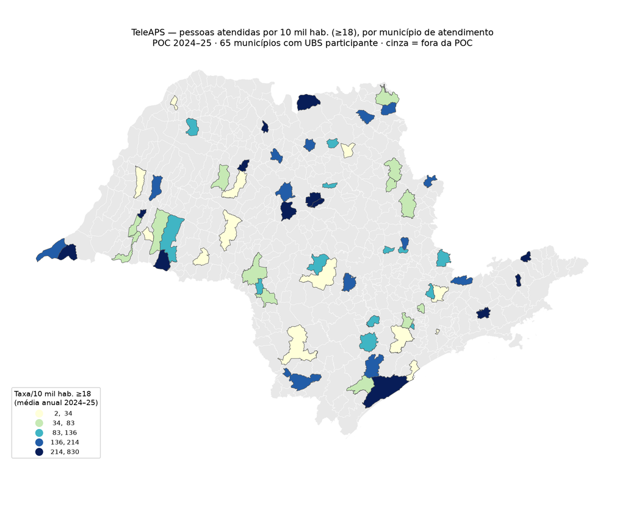

**65 municípios** com UBS participante, em todas as regiões do estado.

Escala **/10 mil hab.** (no municipal, /100k inflava a leitura em cidades pequenas).

Cinza = fora da POC — **não** é taxa zero.

## Cuidado de leitura — e um pedido novo

**Taxa municipal ≠ desempenho da unidade.**

- Ipiguá: 830/10 mil — a **única** UBS da cidade está na POC (cobertura quase total)
- Botucatu: 7,4/10 mil — **1 UBS entre dezenas** da rede municipal
- A taxa mede a *fração da rede que participa*, não a qualidade

**Para comparar unidades de verdade:** população **adscrita** por UBS (SISAB/e-Gestor) como denominador — candidato a próximo pedido/análise conjunta.

## Onde estão as pessoas atendidas

Top unidades (pessoas ≥18, 2024–25) — tabela completa disponível por UBS/ano:

| Unidade | Município | Pessoas |
| --- | --- | --- |
| UBS Sebastião Ferreira da Silveira | Vargem Grande Paulista | 1.060 |
| UBS José Carlos Martins Ribeiro | Iguape | 996 |
| UBS Luis Fachin | Ipiguá | 897 |
| Posto de Saúde 02 | Santa Branca | 731 |
| Macro III Santa Terezinha | Penápolis | 705 |
| PSF Pq. Industrial | Conchal | 639 |

É o insumo direto para a pergunta da SES: **onde expandir**.

## Sugestões — padronizar o envio de dados

O que descobrimos reconstruindo o CNES vale para **todas** as iniciativas:

| # | Sugestão | Por quê |
| --- | --- | --- |
| 1 | **CNES como atributo da opção** no dropdown do REDCap | vira join direto; hoje é reconstrução manual |
| 2 | Exportar o **código da opção** (raw), não só o rótulo | rótulos mudam (“SF”/“ESF”); código é estável |
| 3 | **Dicionário junto com cada export** (mesma data de corte) | dicionário e dados hoje divergem |
| 4 | Formato **CSV/Parquet UTF-8** + nome com data ISO | leitura sem ambiguidade (xlsx ok, mas frágil) |
| 5 | **Periodicidade definida** (ex.: mensal) | nosso pipeline valida e aponta só o que for novo |

## O que já é automático do nosso lado

A cada nova base recebida:

1. `depara_ubs_cnes.py` — valida as unidades: rótulo novo **sem CNES bloqueia** e lista o que curar (auditável, com fonte por linha)
2. `taxa_100k.py` — taxa estadual padronizada (busca Estimativas IBGE via API)
3. `taxa_100k_municipio.py` — taxas municipais (/100k e /10 mil), casos por unidade e mapa

**Rodar = 3 comandos.** Aprendizados e decisões registrados em CHANGELOG e documentação no repositório.

## Seguem em aberto (de 30/06)

| Pedido | Status |
| --- | --- |
| **Bases REDCap completas** | ○ POC 2024–25 ainda é a base |
| **Dicionário atualizado + escopo dos módulos ausentes** | ○ ~277/506 vars sem correspondência no gold |
| **Semântica da “UBS do atendimento”** | ◐ confirmar que é local do atendimento |

**Em curso (C4):** T2 população · T3 encaminhamentos · encaminhamentos por idade (oftalmo × idosos).

### Obrigado

Bragatte, M.A.S · Bolsa PDI 2026 · TO 212.435

*em 1 semana: taxa padronizada, CNES 70/70, mapa real — e um caminho para automatizar tudo*